# Current Data Analysis for the Facial Expression/Cortisol Project

Julianna Calabrese

1/19/2019

## Introduction

In this file, I do my best to follow the instructions as laid out in Lopez-Duran, Mayer, & Abelson 2014. I wil try to explain all the code written in this file, why I do it, and why things may look weird at times. I will also try to name objects, variables, and models as consistently as possible.

Since Lopez-Duran, Mayer, & Abelson’s 2014 paper utilized the PROC MIXED command in SAS, this RMarkdown file will use the lmer() command as part of the lme4 package. More information about lmer() can be found here: https://cran.r-project.org/web/packages/SASmixed/vignettes/Usinglmer.pdf

## Model building

### Equation from Lopez-Duran 2014

$\begin{aligned} Cortisol = \beta_0 & + (\beta_1 \cdot Sex) \\ & + (\beta_2 \cdot TimeBeforePeak) \\ & + (\beta_3 \cdot TimeAfterPeak) \\ & + (\beta_4 \cdot Sex \cdot TimeBeforePeak) \\ & + (\beta_5 \cdot Sex \cdot TimeAfterPeak) \\ \end{aligned}$

### Definitions

- b0 = intercept aka peak
- b1 = the impact of sex on levels at the group peak time
- b2 = the activation slope for males
- b3 = the regulation slope for males
- b4 = the impact of sex (females) on the activation slope
- b5 = the impact of sex (females) on the regulation slope
- timebeforepeak = the reactivity slope / activation
- timeafterpeak = the recovery slope / regulation

The variable “gender” is a binary variable of 0 = male and 1 = female.

## Model using actual time values

The model below (aka “mod1”) uses variables that were made using the variables “stimeC” and “peaktimenumC”. “stime” is the actual time variable (e.g. 837, 844, 855) and “peaktimenum” is the time when the participant’s cortisol value (“cortvalue”) was highest. Therefore, for all the rows that have ID 10003, each row has a different “stime” value (e.g. 837, 844, 855, …), but each row has the same “peaktimenum” value (e.g. 844, 844, 844, …), indicating that the highest cortisol value was observed at stime 844. “stimeC” is the zero-centered version of “stime” and “peaktimenumC” is the zero-centered version of “peaktimenum”.

The variable “peaknamenum” corresponds to the order in which the sample were taken. For example, for ID 10003, the time at which his cortisol peaked was 844, which was the second sample taken (out of the nine samples related to the SECPT). Therefore, for ID 10003, his “peaknamenum” is “2”.

Therefore, we want “peaknamenum” to be a character, but we want almost everything else to be numeric or an integer.

```r
mod1 <- lmer(cortvalue ~ (gender) + (timebeforepeak) + (timeafterpeak) + (gender*timebeforepeak) + (gender*timeafterpeak) + (1|id) + (1|stimeC), data = cp_long, REML=TRUE)
summary(mod1)
```

Base Model Summary Output (mod1)

|  | Cortisol |  |  |  |
| --- | --- | --- | --- | --- |
| Predictors | Estimates | DF | Standard Error | P-value |
| Intercept | 3.48 | 222.00 | 0.10 | **<0.001** |
| Gender | -0.23 | 221.00 | 0.13 | 0.083 |
| TimeBeforePeak | 0.90 | 1366.00 | 0.07 | **<0.001** |
| TimeAfterPeak | -0.32 | 1426.00 | 0.08 | **<0.001** |
| Sex * TimeBeforePeak | 0.14 | 1496.00 | 0.10 | 0.148 |
| Sex * TimeAfterPeak | -0.11 | 1576.00 | 0.11 | 0.281 |
| Observations | 1665 |  |  |  |
| Marginal R<sup>2</sup> / Conditional R<sup>2</sup> | 0.096 / 0.739 |  |  |  |

## Model using “sample” time values

In cp_long, “samplepeaknamenum” is the variable that corresponds to the nine samples and the amount of minutes after the cold press task: 0, 3, 15, 25, 30, 35, 40, 45, 60.

Like shown above, alternatives include “stime” or “stimeC” (which is stime but zero-centered), which is the actual amount of minutes between each sample (e.g. 837, 844, 855, …) or timenum, which is the mostly just the sample number. timenum is 4, 5, 6, 7, 8, 9, 10, 11, and 12, while timenum is “centered” (not really though–it just assumes that the fourth sample is actually the first sample, since we don’t care about cortisol levels during the MRI) and is 1, 2, 3, 4, 5, 6, 7, 8, and 9.

Therefore, any variable that begins with “sample” is based off this 0, 3, 15, etc. sequence: samplepeaknamenum, sampletimetopeak, sampletimebeforepeak, and sampletimeafterpeak. The reason I went with the “sample” version of the time variable is because we would be able to treat time as a factor instead of as an integer or as a numeric variable.

As opposed to the first model, I believe that the second model is the closest to the model in Lopez-Duran 2014 as possible.

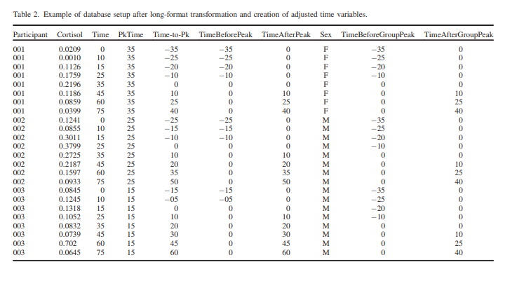

According to Table 2 in Lopez-Duran 2014, there were no “actual time” values (i.e. 837, 844, 855, …), just the “minute” values (i.e. 0, 3, 15, …).

Additionally, in his table, gender is M/F. So I transformed “gender” and “female” from integers to character variables, which makes them identical to a M/F system.

```r
mod2 <- lmer(cortvalue ~ (gender) + (sampletimebeforepeak) + (sampletimeafterpeak) + (gender*sampletimebeforepeak) + (gender*sampletimeafterpeak) + (1|id) + (1|sampletime), data = cp_long, REML=TRUE)
summary(mod2)
```

Base Model Summary Output (mod2)

|  | Cortisol |  |  |  |
| --- | --- | --- | --- | --- |
| Predictors | Estimates | DF | Standard Error | P-value |
| Intercept | 3.52 | 52.00 | 0.12 | **<0.001** |
| Gender | -0.20 | 217.00 | 0.13 | 0.124 |
| TimeBeforePeak | 0.01 | 67.00 | 0.00 | **<0.001** |
| TimeAfterPeak | -0.02 | 111.00 | 0.00 | **<0.001** |
| Sex * TimeBeforePeak | 0.00 | 1519.00 | 0.00 | 0.058 |
| Sex * TimeAfterPeak | -0.00 | 1553.00 | 0.00 | 0.069 |
| Observations | 1665 |  |  |  |
| Marginal R<sup>2</sup> / Conditional R<sup>2</sup> | 0.112 / 0.759 |  |  |  |

## Base model findings

Both mod1 and mod2 have significant results.

In mod1, intercept (aka peak), timebeforepeak, and timeafterpeak are significant, while gender has a p-value of 0.0835. In mod2, intercept (aka peak), sampletimebeforepeak, and sampletimeafterpeak are significant. Gender is even “less significant” with a p-value of 0.1245.

```r
pander(anova(mod1, mod2))
```

refitting model(s) with ML (instead of REML)

Data: cp_long

|  | Df | AIC | BIC | logLik | deviance | Chisq | Chi Df | Pr(>Chisq) |
| --- | --- | --- | --- | --- | --- | --- | --- | --- |
| **mod1** | 9 | 3274 | 3323 | -1628 | 3256 | NA | NA | NA |
| **mod2** | 9 | 3097 | 3146 | -1539 | 3079 | 177 | 0 | 0 |

However, it looks like mod2 has the better fit, so I will abandon mod1 and rename mod2 to ‘base’.

## Base model visualizations

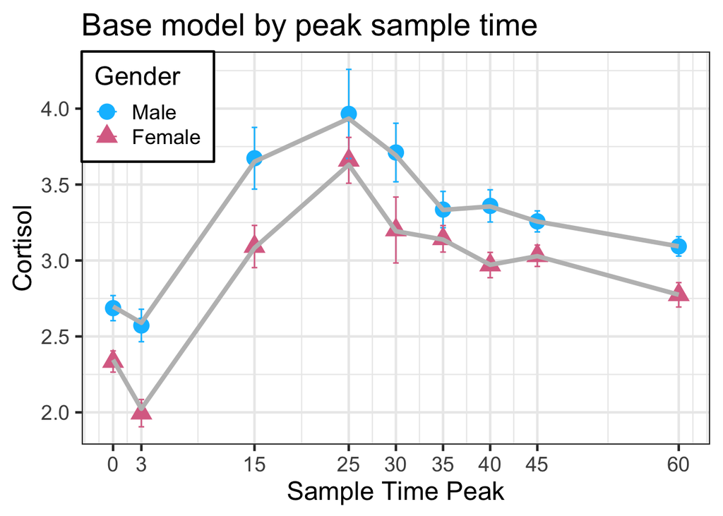

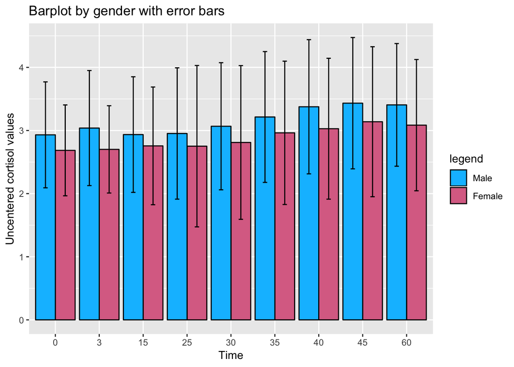

## Adding emotion to base model

### Anger

```r
anger <- lmer(cortvalue ~ (gender) + (sampletimebeforepeak) + (sampletimeafterpeak) + (gender*sampletimebeforepeak) + (gender*sampletimeafterpeak) + angerC + (1|id) + (1|sampletime), data = cp_long, REML=TRUE)
summary(anger)
```

Anger Model Summary Output

|  | Cortisol |  |  |  |
| --- | --- | --- | --- | --- |
| Predictors | Estimates | DF | Standard Error | P-value |
| Intercept | 3.53 | 52.00 | 0.12 | **<0.001** |
| Gender | -0.20 | 215.00 | 0.13 | 0.113 |
| TimeBeforePeak | 0.01 | 67.00 | 0.00 | **<0.001** |
| TimeAfterPeak | -0.02 | 111.00 | 0.00 | **<0.001** |
| Anger | -0.03 | 181.00 | 0.06 | 0.591 |
| Sex * TimeBeforePeak | 0.00 | 1519.00 | 0.00 | 0.059 |
| Sex * TimeAfterPeak | -0.00 | 1552.00 | 0.00 | 0.068 |
| Observations | 1665 |  |  |  |
| Marginal R<sup>2</sup> / Conditional R<sup>2</sup> | 0.112 / 0.759 |  |  |  |

Anger is not significant.

### Fear

```r
fear <- lmer(cortvalue ~ (gender) + (sampletimebeforepeak) + (sampletimeafterpeak) + (gender*sampletimebeforepeak) + (gender*sampletimeafterpeak) + fearC + (1|id) + (1|sampletime), data = cp_long, REML=TRUE)
summary(fear)
```

Fear Model Summary Output

|  | Cortisol |  |  |  |
| --- | --- | --- | --- | --- |
| Predictors | Estimates | DF | Standard Error | P-value |
| Intercept | 3.53 | 52.00 | 0.12 | **<0.001** |
| Gender | -0.20 | 214.00 | 0.13 | 0.116 |
| TimeBeforePeak | 0.01 | 67.00 | 0.00 | **<0.001** |
| TimeAfterPeak | -0.02 | 110.00 | 0.00 | **<0.001** |
| Fear | -0.03 | 182.00 | 0.06 | 0.681 |
| Sex * TimeBeforePeak | 0.00 | 1519.00 | 0.00 | 0.058 |
| Sex * TimeAfterPeak | -0.00 | 1553.00 | 0.00 | 0.069 |
| Observations | 1665 |  |  |  |
| Marginal R<sup>2</sup> / Conditional R<sup>2</sup> | 0.112 / 0.759 |  |  |  |

Fear is not significant.

### Happiness

```r
happy <- lmer(cortvalue ~ (gender) + (sampletimebeforepeak) + (sampletimeafterpeak) + (gender*sampletimebeforepeak) + (gender*sampletimeafterpeak) + happinessC + (1|id) + (1|sampletime), data = cp_long, REML=TRUE)
summary(happy)
```

Happy Model Summary Output

|  | Cortisol |  |  |  |
| --- | --- | --- | --- | --- |
| Predictors | Estimates | DF | Standard Error | P-value |
| Intercept | 3.53 | 54.00 | 0.12 | **<0.001** |
| Gender | -0.20 | 214.00 | 0.13 | 0.125 |
| TimeBeforePeak | 0.01 | 65.00 | 0.00 | **<0.001** |
| TimeAfterPeak | -0.02 | 107.00 | 0.00 | **<0.001** |
| Happiness | 0.01 | 182.00 | 0.06 | 0.876 |
| Sex * TimeBeforePeak | 0.00 | 1519.00 | 0.00 | 0.058 |
| Sex * TimeAfterPeak | -0.00 | 1553.00 | 0.00 | 0.069 |
| Observations | 1665 |  |  |  |
| Marginal R<sup>2</sup> / Conditional R<sup>2</sup> | 0.111 / 0.759 |  |  |  |

Happiness is not significant.

### Sadness

```r
sad <- lmer(cortvalue ~ (gender) + (sampletimebeforepeak) + (sampletimeafterpeak) + (gender*sampletimebeforepeak) + (gender*sampletimeafterpeak) + sadnessC + (1|id) + (1|sampletime), data = cp_long, REML=TRUE)
summary(sad)
```

Sad Model Summary Output

|  | Cortisol |  |  |  |
| --- | --- | --- | --- | --- |
| Predictors | Estimates | DF | Standard Error | P-value |
| Intercept | 3.53 | 53.00 | 0.12 | **<0.001** |
| Gender | -0.20 | 215.00 | 0.13 | 0.119 |
| TimeBeforePeak | 0.01 | 66.00 | 0.00 | **<0.001** |
| TimeAfterPeak | -0.02 | 110.00 | 0.00 | **<0.001** |
| Sadness | -0.06 | 181.00 | 0.06 | 0.365 |
| Sex * TimeBeforePeak | 0.00 | 1519.00 | 0.00 | 0.059 |
| Sex * TimeAfterPeak | -0.00 | 1553.00 | 0.00 | 0.070 |
| Observations | 1665 |  |  |  |
| Marginal R<sup>2</sup> / Conditional R<sup>2</sup> | 0.113 / 0.759 |  |  |  |

Sadness is not significant.

### Pain

```r
pain <- lmer(cortvalue ~ (gender) + (sampletimebeforepeak) + (sampletimeafterpeak) + (gender*sampletimebeforepeak) + (gender*sampletimeafterpeak) + painC + (1|id) + (1|sampletime), data = cp_long, REML=TRUE)
summary(pain)
```

Pain Model Summary Output

|  | Cortisol |  |  |  |
| --- | --- | --- | --- | --- |
| Predictors | Estimates | DF | Standard Error | P-value |
| Intercept | 3.53 | 52.00 | 0.12 | **<0.001** |
| Gender | -0.20 | 215.00 | 0.13 | 0.119 |
| TimeBeforePeak | 0.01 | 67.00 | 0.00 | **<0.001** |
| TimeAfterPeak | -0.02 | 111.00 | 0.00 | **<0.001** |
| Pain | -0.03 | 182.00 | 0.06 | 0.625 |
| Sex * TimeBeforePeak | 0.00 | 1519.00 | 0.00 | 0.058 |
| Sex * TimeAfterPeak | -0.00 | 1553.00 | 0.00 | 0.069 |
| Observations | 1665 |  |  |  |
| Marginal R<sup>2</sup> / Conditional R<sup>2</sup> | 0.112 / 0.759 |  |  |  |

Pain is not significant.

## Emotion model conclusions

From first glance, looks like none of the emotions have reached the alpha < 0.05 threshold. Now I will compared which models have better fit than the others.

```r
pander(anova(base, anger, fear, happy, sad, pain))
```

refitting model(s) with ML (instead of REML)

Data: cp_long

|  | Df | AIC | BIC | logLik | deviance | Chisq | Chi Df | Pr(>Chisq) |
| --- | --- | --- | --- | --- | --- | --- | --- | --- |
| **base** | 9 | 3097 | 3146 | -1539 | 3079 | NA | NA | NA |
| **anger** | 10 | 3099 | 3153 | -1539 | 3079 | 0.2815 | 1 | 0.5957 |
| **fear** | 10 | 3099 | 3153 | -1539 | 3079 | 0 | 0 | 1 |
| **happy** | 10 | 3099 | 3153 | -1539 | 3079 | 0 | 0 | 1 |
| **sad** | 10 | 3098 | 3152 | -1539 | 3078 | 0.8092 | 0 | 0 |
| **pain** | 10 | 3099 | 3153 | -1539 | 3079 | 0 | 0 | 1 |

```r
pander(anova(base, sad))
```

refitting model(s) with ML (instead of REML)

Data: cp_long

|  | Df | AIC | BIC | logLik | deviance | Chisq | Chi Df | Pr(>Chisq) |
| --- | --- | --- | --- | --- | --- | --- | --- | --- |
| **base** | 9 | 3097 | 3146 | -1539 | 3079 | NA | NA | NA |
| **sad** | 10 | 3098 | 3152 | -1539 | 3078 | 0.8413 | 1 | 0.359 |

```r
pander(anova(base, anger))
```

refitting model(s) with ML (instead of REML)

Data: cp_long

|  | Df | AIC | BIC | logLik | deviance | Chisq | Chi Df | Pr(>Chisq) |
| --- | --- | --- | --- | --- | --- | --- | --- | --- |
| **base** | 9 | 3097 | 3146 | -1539 | 3079 | NA | NA | NA |
| **anger** | 10 | 3099 | 3153 | -1539 | 3079 | 0.2815 | 1 | 0.5957 |

```r
pander(anova(anger, fear, happy, sad, pain))
```

refitting model(s) with ML (instead of REML)

Data: cp_long

|  | Df | AIC | BIC | logLik | deviance | Chisq | Chi Df | Pr(>Chisq) |
| --- | --- | --- | --- | --- | --- | --- | --- | --- |
| **anger** | 10 | 3099 | 3153 | -1539 | 3079 | NA | NA | NA |
| **fear** | 10 | 3099 | 3153 | -1539 | 3079 | 0 | 0 | 1 |
| **happy** | 10 | 3099 | 3153 | -1539 | 3079 | 0 | 0 | 1 |
| **sad** | 10 | 3098 | 3152 | -1539 | 3078 | 0.8092 | 0 | 0 |
| **pain** | 10 | 3099 | 3153 | -1539 | 3079 | 0 | 0 | 1 |

Base model vs. sad model

|  | Base |  |  |  | Sadness |  |  |  |
| --- | --- | --- | --- | --- | --- | --- | --- | --- |
| Predictors | Estimates | DF | Standard Error | P-value | Estimates | DF | Standard Error | P-value |
| Intercept | 3.52 | 52.00 | 0.12 | **<0.001** | 3.53 | 53.00 | 0.12 | **<0.001** |
| Gender | -0.20 | 217.00 | 0.13 | 0.124 | -0.20 | 215.00 | 0.13 | 0.119 |
| TimeBeforePeak | 0.01 | 67.00 | 0.00 | **<0.001** | 0.01 | 66.00 | 0.00 | **<0.001** |
| TimeAfterPeak | -0.02 | 111.00 | 0.00 | **<0.001** | -0.02 | 110.00 | 0.00 | **<0.001** |
| Sex * TimeBeforePeak | 0.00 | 1519.00 | 0.00 | 0.058 | 0.00 | 1519.00 | 0.00 | 0.059 |
| Sex * TimeAfterPeak | -0.00 | 1553.00 | 0.00 | 0.069 | -0.00 | 1553.00 | 0.00 | 0.070 |
| Sadness |  |  |  |  | -0.06 | 181.00 | 0.06 | 0.365 |
| Observations | 1665 |  |  |  | 1665 |  |  |  |
| Marginal R<sup>2</sup> / Conditional R<sup>2</sup> | 0.112 / 0.759 |  |  |  | 0.113 / 0.759 |  |  |  |

## Sad model visualization

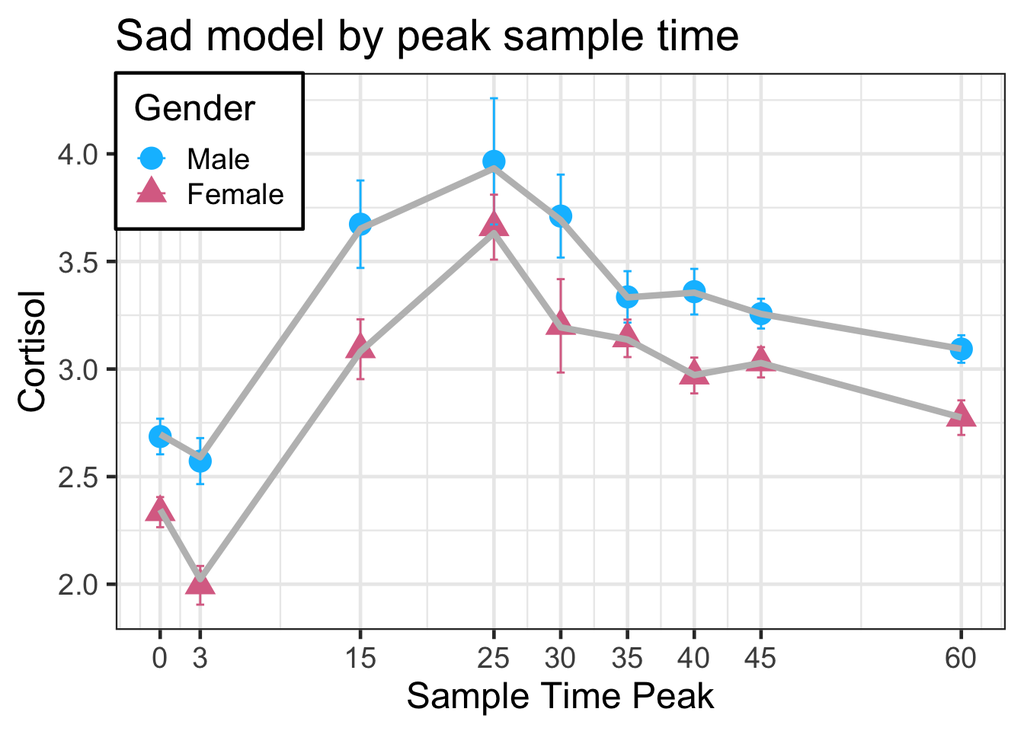

## Adding CTQ to base model

Although nothing so far has definitively reached the alpha < 0.05 threshold, let’s try adding ctq to see if it makes a difference. Here is the CTQ base model.

```r
ctq <- lmer(cortvalue ~ (gender) + (sampletimebeforepeak) + (sampletimeafterpeak) + (gender*sampletimebeforepeak) + (gender*sampletimeafterpeak) + ctqsumC + (1|id) + (1|sampletime), data = cp_long, REML=TRUE)
summary(ctq)
```

|  | Cortisol |  |  |  |
| --- | --- | --- | --- | --- |
| Predictors | Estimates | DF | Standard Error | P-value |
| Intercept | 3.52 | 54.00 | 0.12 | **<0.001** |
| Gender | -0.19 | 215.00 | 0.13 | 0.135 |
| TimeBeforePeak | 0.01 | 65.00 | 0.00 | **<0.001** |
| TimeAfterPeak | -0.02 | 109.00 | 0.00 | **<0.001** |
| CTQ Total Sum | 0.07 | 181.00 | 0.06 | 0.262 |
| Sex * TimeBeforePeak | 0.00 | 1519.00 | 0.00 | 0.059 |
| Sex * TimeAfterPeak | -0.00 | 1553.00 | 0.00 | 0.070 |
| Observations | 1665 |  |  |  |
| Marginal R<sup>2</sup> / Conditional R<sup>2</sup> | 0.117 / 0.760 |  |  |  |

```r
pander(anova(base, ctq))
```

refitting model(s) with ML (instead of REML)

Data: cp_long

|  | Df | AIC | BIC | logLik | deviance | Chisq | Chi Df | Pr(>Chisq) |
| --- | --- | --- | --- | --- | --- | --- | --- | --- |
| **base** | 9 | 3097 | 3146 | -1539 | 3079 | NA | NA | NA |
| **ctq** | 10 | 3098 | 3152 | -1539 | 3078 | 1.299 | 1 | 0.2545 |

Addding CTQ Total Sum to the base model does not make any difference. Let’s now add CTQ to the sad model.

In our dataset, we have CTQ Total Sum (“ctqsumC”). Let’s see if adding CTQ to “sad” will make any difference. We will use the zero-centered version of CTQ Total Sum.

```
## Linear mixed model fit by REML. t-tests use Satterthwaite's method [
## lmerModLmerTest]
## Formula:
## cortvalue ~ (gender) + (sampletimebeforepeak) + (sampletimeafterpeak) +
##     (gender * sampletimebeforepeak) + (gender * sampletimeafterpeak) +
##     sadnessC + ctqsumC + (1 | id) + (1 | sampletime)
##    Data: cp_long
##
## REML criterion at convergence: 3131.8
##
## Scaled residuals:
##     Min      1Q  Median      3Q     Max
## -5.4265 -0.4934 -0.0443  0.4399 10.5271
##
## Random effects:
##  Groups     Name        Variance Std.Dev.
##  id         (Intercept) 0.65075  0.8067
##  sampletime (Intercept) 0.04046  0.2011
##  Residual               0.25832  0.5083
## Number of obs: 1665, groups:  id, 185; sampletime, 9
##
## Fixed effects:
##                                Estimate Std. Error         df t value
## (Intercept)                   3.525e+00  1.177e-01  3.648e+01  29.939
## gender1                      -1.945e-01  1.275e-01  2.085e+02  -1.525
## sampletimebeforepeak          1.377e-02  2.623e-03  4.258e+01   5.249
## sampletimeafterpeak          -2.067e-02  2.885e-03  7.215e+01  -7.167
## sadnessC                     -5.733e-02  6.068e-02  1.752e+02  -0.945
## ctqsumC                       7.008e-02  6.076e-02  1.755e+02   1.154
## gender1:sampletimebeforepeak  3.439e-03  1.822e-03  1.519e+03   1.888
## gender1:sampletimeafterpeak  -4.486e-03  2.481e-03  1.553e+03  -1.808
##                              Pr(>|t|)
## (Intercept)                   < 2e-16 ***
## gender1                        0.1287
## sampletimebeforepeak         4.57e-06 ***
## sampletimeafterpeak          5.39e-10 ***
## sadnessC                       0.3461
## ctqsumC                        0.2503
## gender1:sampletimebeforepeak   0.0593 .
## gender1:sampletimeafterpeak    0.0707 .
## ---
## Signif. codes:  0 '***' 0.001 '**' 0.01 '*' 0.05 '.' 0.1 ' ' 1
##
## Correlation of Fixed Effects:
##               (Intr) gendr1 smpltmb smpltmf sdnssC ctqsmC gndr1:smpltmb
## gender1       -0.604
## smpltmbfrpk    0.248 -0.134
## smpltmftrpk    0.021  0.056  0.580
## sadnessC      -0.019  0.025 -0.020  -0.009
## ctqsumC       -0.018  0.036  0.033   0.034  -0.031
## gndr1:smpltmb -0.144  0.245 -0.359   0.085   0.006 -0.004
## gndr1:smpltmf  0.117 -0.196  0.079  -0.480  -0.003  0.004 -0.199
```

Base vs. Sad vs. Sad-CTQ

|  | Base |  |  |  | Sad |  |  |  | Sad-CTQ |  |  |  |
| --- | --- | --- | --- | --- | --- | --- | --- | --- | --- | --- | --- | --- |
| Predictors | Estimates | DF | Standard Error | P-value | Estimates | DF | Standard Error | P-value | Estimates | DF | Standard Error | P-value |
| Intercept | 3.52 | 52.00 | 0.12 | **<0.001** | 3.53 | 53.00 | 0.12 | **<0.001** | 3.53 | 54.00 | 0.12 | **<0.001** |
| Gender | -0.20 | 217.00 | 0.13 | 0.124 | -0.20 | 215.00 | 0.13 | 0.119 | -0.19 | 214.00 | 0.13 | 0.129 |
| TimeBeforePeak | 0.01 | 67.00 | 0.00 | **<0.001** | 0.01 | 66.00 | 0.00 | **<0.001** | 0.01 | 65.00 | 0.00 | **<0.001** |
| TimeAfterPeak | -0.02 | 111.00 | 0.00 | **<0.001** | -0.02 | 110.00 | 0.00 | **<0.001** | -0.02 | 108.00 | 0.00 | **<0.001** |
| Sex * TimeBeforePeak | 0.00 | 1519.00 | 0.00 | 0.058 | 0.00 | 1519.00 | 0.00 | 0.059 | 0.00 | 1519.00 | 0.00 | 0.059 |
| Sex * TimeAfterPeak | -0.00 | 1553.00 | 0.00 | 0.069 | -0.00 | 1553.00 | 0.00 | 0.070 | -0.00 | 1553.00 | 0.00 | 0.071 |
| Sadness |  |  |  |  | -0.06 | 181.00 | 0.06 | 0.365 | -0.06 | 180.00 | 0.06 | 0.346 |
| CTQ Total Sum |  |  |  |  |  |  |  |  | 0.07 | 180.00 | 0.06 | 0.250 |
| Observations | 1665 |  |  |  | 1665 |  |  |  | 1665 |  |  |  |
| Marginal R<sup>2</sup> / Conditional R<sup>2</sup> | 0.112 / 0.759 |  |  |  | 0.113 / 0.759 |  |  |  | 0.119 / 0.760 |  |  |  |

```r
pander(anova(base, sad, ctq, sadctq))
```

refitting model(s) with ML (instead of REML)

Data: cp_long

|  | Df | AIC | BIC | logLik | deviance | Chisq | Chi Df | Pr(>Chisq) |
| --- | --- | --- | --- | --- | --- | --- | --- | --- |
| **base** | 9 | 3097 | 3146 | -1539 | 3079 | NA | NA | NA |
| **sad** | 10 | 3098 | 3152 | -1539 | 3078 | 0.8413 | 1 | 0.359 |
| **ctq** | 10 | 3098 | 3152 | -1539 | 3078 | 0.4572 | 0 | 0 |
| **sadctq** | 11 | 3099 | 3158 | -1538 | 3077 | 0.9154 | 1 | 0.3387 |